# Компьютерный практикум по статистическому анализу данных. Лаб №3

Управляющие структуры

Шаповалова Диана Дмитриевна

Российский университет дружбы народов, Москва, Россия

28 ноября 2024

# Вводная часть

## Цель работы

Основная цель работы — освоить применение циклов функций и сторонних для Julia пакетов для решения задач линейной алгебры и работы с матрицами.

# Выполнение лабораторной работы

## Циклы while и for

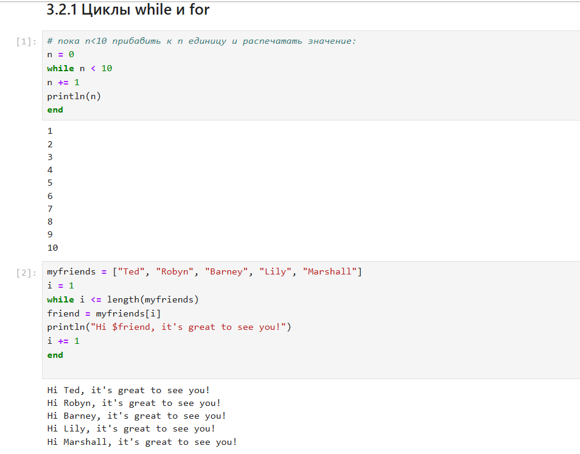

Выполняем примеры по циклам while и for

## Условные выражения

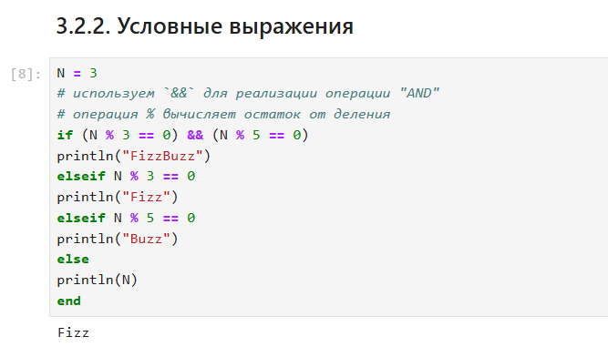

Выполняем примеры по условным выражениям

## Функции, Сторонние библиотеки (пакеты) в Julia

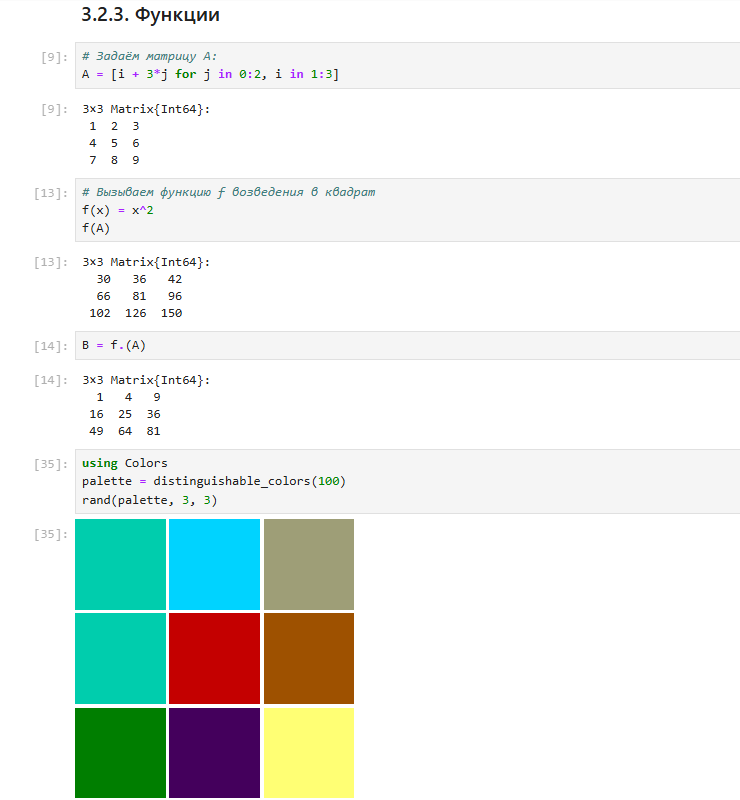

Выполняем примеры по функциям и сторонним библиотекам

# Задания для самостоятельного выполнения

## 1. Используя циклы while и for: – выведите на экран целые числа от 1 до 100 и напечатайте их квадраты;

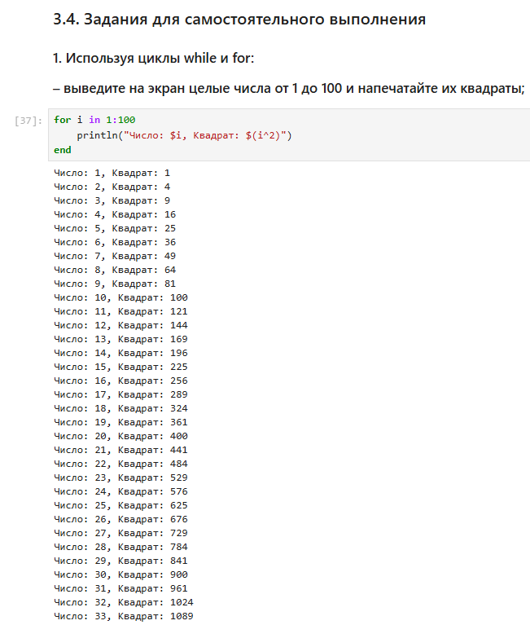

Задание №1

## – создайте словарь squares, который будет содержать целые числа в качестве ключей и квадраты в качестве их пар-значений; – создайте массив squares_arr, содержащий квадраты всех чисел от 1 до 100.

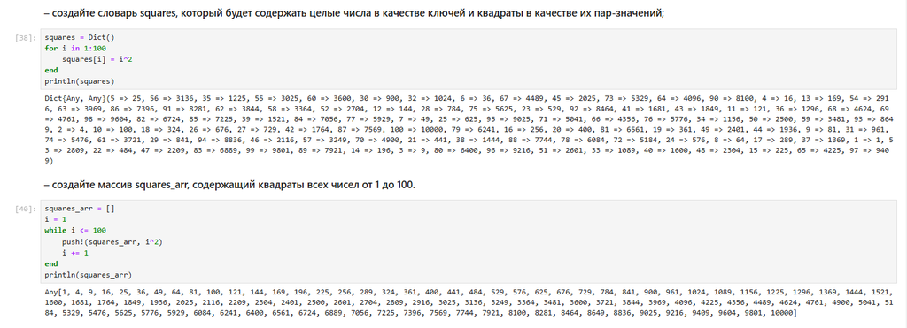

Задание №1

## 2. Напишите условный оператор, который печатает число, если число чётное, и строку «нечётное», если число нечётное. Перепишите код, используя тернарный оператор. 3. Напишите функцию add_one, которая добавляет 1 к своему входу.

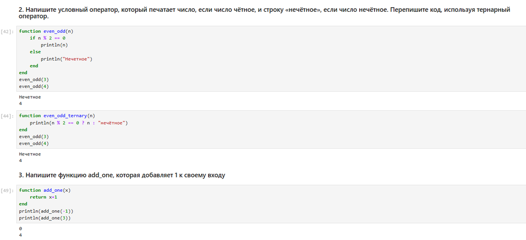

Задание №2 и 3

## 4. Используйте map() или broadcast() для задания матрицы 𝐴, каждый элемент которой увеличивается на единицу по сравнению с предыдущим.

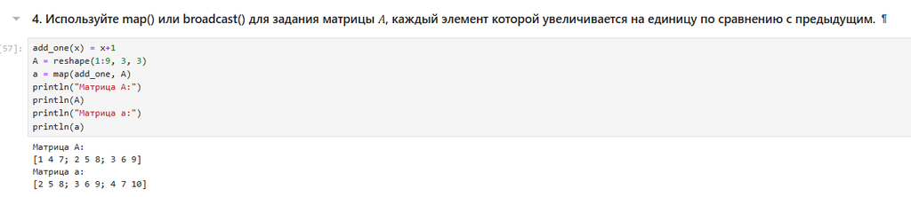

Задание №4

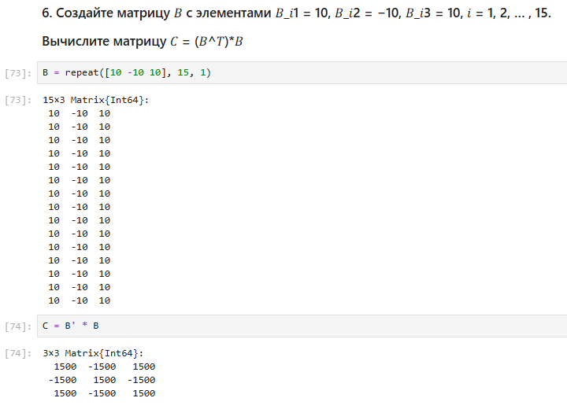

Задание №6

## 7. Создайте матрицу 𝑍 размерности 6 × 6, все элементы которой равны нулю, и матрицу 𝐸, все элементы которой равны 1. Используя цикл while или for и закономерности расположения элементов, создайте следующие матрицы размерности 6 × 6

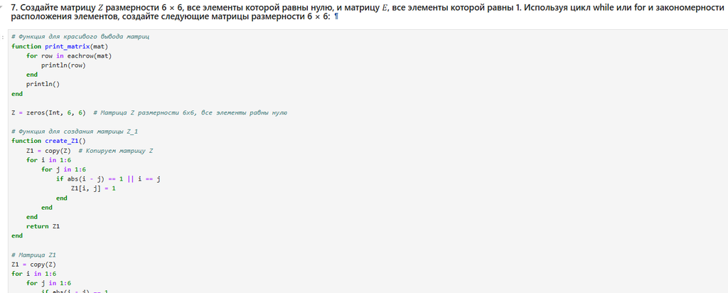

Задание №7

## 8. Напишите свою функцию, аналогичную функции outer() языка R.

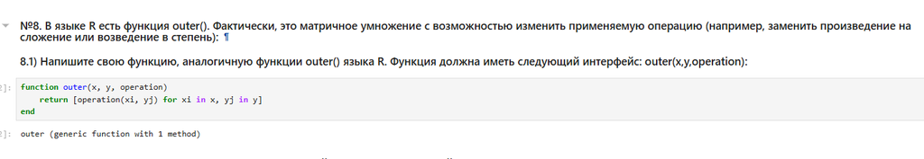

Задание №8

## Используя написанную вами функцию outer(), создайте матрицы следующей структуры

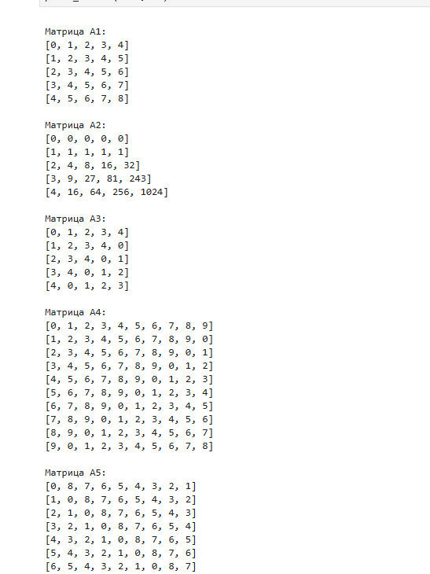

Задание №8

## 9. Решите следующую систему линейных уравнений с 5 неизвестными

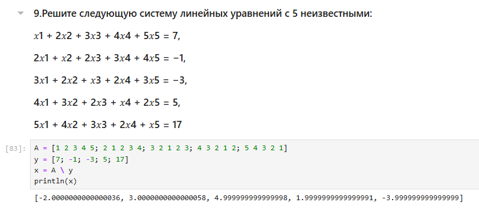

Задание №9

## 10. Создайте матрицу 𝑀 размерности 6 × 10, элементами которой являются целые числа, выбранные случайным образом с повторениями из совокупности 1, 2, … , 10.

– Найдите число элементов в каждой строке матрицы 𝑀, которые больше числа 𝑁 (например, 𝑁 = 4).

– Определите, в каких строках матрицы𝑀число𝑀(например,𝑀 = 7) встречается ровно 2 раза?

## Задание 10

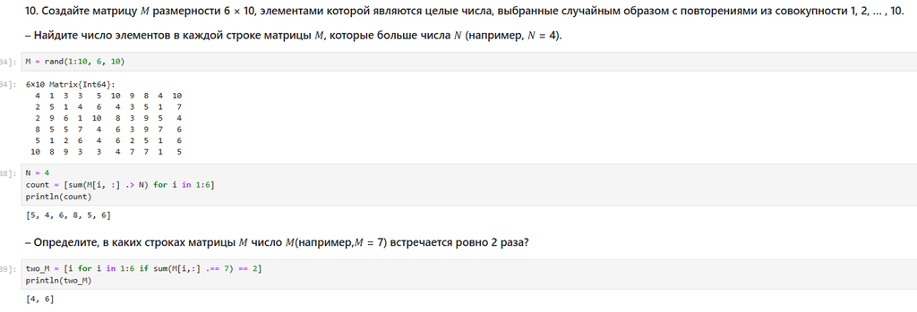

Задание №10

## – Определите все пары столбцов матрицы 𝑀, сумма элементов которых больше 𝐾 (например, 𝐾 = 75).

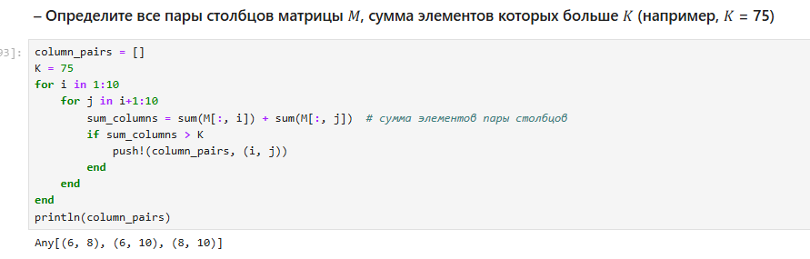

Задание №10

## 11. Вычислите

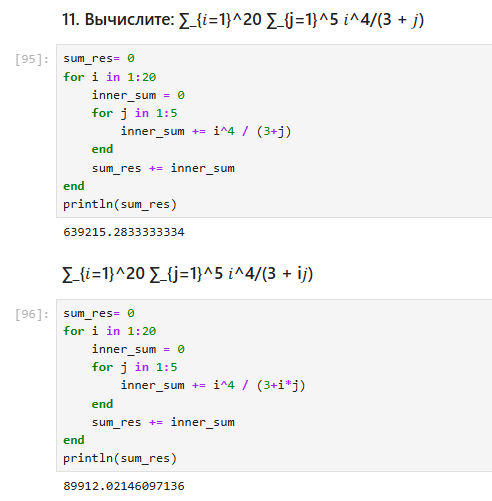

Задание №11

# Выводы

Мы освоили применение циклов функций и сторонних для Julia пакетов для решения задач линейной алгебры и работы с матрицами.